# Stylistic Dispersion — Visualizations

Renders every visualization produced by `dispersion_regression.R` (the primary analysis pipeline), plus a few additional views that summarize findings which only existed as tables before now (the rating-level heatmap in particular — see section 5).

Replaces `convergence_viz.R`, which was built around `convergence_fanfic.R`’s outputs; that script and its brms cache files were deleted once the primary analysis moved to the OLS + shrinkage approach here.

```r
# runs the full pipeline: data prep, all OLS fits, all three stage-2 pooling
# models. The three brms models load from outputs/brms_cache/ if unchanged
# (a few seconds); only refits if the cache is stale or missing.
source("dispersion_regression.R")
```

```
# A tibble: 60 × 6
   fandom factor  estimate std.error   p.value direction
   <chr>  <chr>      <dbl>     <dbl>     <dbl> <chr>
 1 HP     F1      0.0328     0.0137  0.0166    diverging
 2 HP     F2     -0.0117     0.0136  0.388     no credible change
 3 HP     F3      0.0146     0.0121  0.229     no credible change
 4 HP     F4     -0.00558    0.0130  0.667     no credible change
 5 HP     F5      0.00129    0.0129  0.920     no credible change
 6 HP     F6     -0.00925    0.0137  0.500     no credible change
 7 HP     F7      0.000938   0.0127  0.941     no credible change
 8 HP     F8      0.0202     0.0132  0.126     no credible change
 9 HP     F9      0.00345    0.0132  0.793     no credible change
10 HP     F10    -0.00302    0.0137  0.825     no credible change
11 LOTR   F1      0.00271    0.0113  0.810     no credible change
12 LOTR   F2     -0.0117     0.0128  0.363     no credible change
```

[output cut: 48 more lines]

```
# A tibble: 50 × 7
   fandom factor raw_estimate shrunk_estimate shrunk_lo95 shrunk_hi95 direction
   <fct>  <chr>         <dbl>           <dbl>       <dbl>       <dbl> <chr>
 1 HP     F1         0.0328          0.0180      0.00328      0.0338  diverging
 2 HP     F2        -0.0117         -0.00810    -0.0239       0.00791 no credib…
 3 HP     F3         0.0146          0.00813    -0.00501      0.0218  no credib…
 4 HP     F4        -0.00558        -0.00883    -0.0237       0.00669 no credib…
 5 HP     F5         0.00129         0.00812    -0.00575      0.0217  no credib…
 6 HP     F6        -0.00925         0.00318    -0.00986      0.0170  no credib…
 7 HP     F7         0.000938        0.00457    -0.00911      0.0184  no credib…
 8 HP     F8         0.0202          0.00642    -0.00637      0.0194  no credib…
 9 HP     F9         0.00345         0.00650    -0.00699      0.0198  no credib…
10 HP     F10       -0.00302         0.0107     -0.00378      0.0251  no credib…
11 LOTR   F1         0.00271         0.0131     -0.00190      0.0282  no credib…
12 LOTR   F2        -0.0117         -0.0130     -0.0286       0.00244 no credib…
```

[output cut: 38 more lines]

```
# A tibble: 10 × 6
   fandom factor  estimate std.error p.value direction
   <chr>  <chr>      <dbl>     <dbl>   <dbl> <chr>
 1 random F1      0.0196     0.0113   0.0845 no credible change
 2 random F2      0.0197     0.0111   0.0766 no credible change
 3 random F3     -0.00544    0.00941  0.563  no credible change
 4 random F4     -0.000739   0.00878  0.933  no credible change
 5 random F5     -0.0145     0.00955  0.129  no credible change
 6 random F6      0.0126     0.0102   0.219  no credible change
 7 random F7      0.00580    0.00975  0.552  no credible change
 8 random F8      0.000152   0.0102   0.988  no credible change
 9 random F9     -0.00498    0.00947  0.599  no credible change
10 random F10     0.0118     0.00979  0.228  no credible change
```

```
# A tibble: 24 × 3
   fandom term            vif
   <fct>  <chr>         <dbl>
 1 HP     time           1.01
 2 HP     logwords       1.02
 3 HP     growth_resid   1.00
 4 HP     is_new_author  1.01
 5 LOTR   time           1.00
 6 LOTR   logwords       1.01
 7 LOTR   growth_resid   1.00
 8 LOTR   is_new_author  1.01
 9 MAG    time           1.00
10 MAG    logwords       1.01
11 MAG    growth_resid   1.01
12 MAG    is_new_author  1.00
13 PJ     time           1.00
14 PJ     logwords       1.01
15 PJ     growth_resid   1.00
16 PJ     is_new_author  1.01
17 random time           1.00
18 random logwords       1.01
19 random growth_resid   1.00
20 random is_new_author  1.01
21 RPF    time           1.00
22 RPF    logwords       1.01
23 RPF    growth_resid   1.00
24 RPF    is_new_author  1.01
```

```
# A tibble: 6 × 2
  fandom incremental_r2_from_rating
  <chr>                       <dbl>
1 RPF                       0.0326
2 LOTR                      0.0126
3 PJ                        0.00617
4 HP                        0.00525
5 MAG                       0.00519
6 random                    0.00196
```

```
# A tibble: 16 × 9
   fandom factor rating                n_works estimate std.error p.value
   <chr>  <chr>  <chr>                   <int>    <dbl>     <dbl>   <dbl>
 1 HP     F7     Explicit                  590   0.0787    0.0376 0.0365
 2 LOTR   F2     Explicit                  398  -0.0892    0.0407 0.0285
 3 LOTR   F7     Teen And Up Audiences     675  -0.0685    0.0288 0.0177
 4 MAG    F7     Explicit                  424   0.0980    0.0406 0.0158
 5 PJ     F1     Teen And Up Audiences    1053   0.0693    0.0300 0.0207
 6 PJ     F2     Explicit                  236   0.0883    0.0398 0.0264
 7 PJ     F3     Mature                    250   0.0871    0.0419 0.0378
 8 PJ     F8     Explicit                  236  -0.124     0.0418 0.00308
 9 RPF    F4     Explicit                  313   0.171     0.0585 0.00351
10 RPF    F4     Mature                    234   0.156     0.0643 0.0151
11 RPF    F4     Teen And Up Audiences     980   0.134     0.0493 0.00671
12 RPF    F7     Teen And Up Audiences     980   0.147     0.0630 0.0197
13 RPF    F8     Explicit                  313   0.152     0.0765 0.0471
14 RPF    F8     Mature                    234   0.227     0.0842 0.00695
15 RPF    F8     Teen And Up Audiences     980   0.179     0.0645 0.00543
16 random F7     Mature                    393  -0.0783    0.0320 0.0144
# ℹ 2 more variables: baseline_time_estimate <dbl>, total_slope <dbl>
```

```
# A tibble: 150 × 8
    fandom factor rating    raw_estimate shrunk_estimate shrunk_lo95 shrunk_hi95
    <fct>  <fct>  <fct>            <dbl>           <dbl>       <dbl>       <dbl>
  1 HP     F1     Explicit     -0.0240          0.00645   -0.0157        0.0289
  2 HP     F1     Mature        0.0124         -0.00319   -0.0244        0.0189
  3 HP     F1     Teen And…    -0.0342         -0.00654   -0.0279        0.0149
  4 HP     F10    Explicit      0.0241          0.00382   -0.0198        0.0250
  5 HP     F10    Mature        0.00876        -0.00582   -0.0285        0.0159
  6 HP     F10    Teen And…    -0.00196        -0.00917   -0.0313        0.0118
  7 HP     F2     Explicit     -0.0384          0.00319   -0.0199        0.0249
  8 HP     F2     Mature        0.000360       -0.00644   -0.0290        0.0147
  9 HP     F2     Teen And…     0.0149         -0.00980   -0.0318        0.0112
 10 HP     F3     Explicit     -0.0498          0.000575  -0.0237        0.0221
 11 HP     F3     Mature       -0.0717         -0.00906   -0.0334        0.0122
 12 HP     F3     Teen And…    -0.0683         -0.0124    -0.0361        0.00871
```

[output cut: 139 more lines]

```
# A tibble: 1 × 9
  fandom factor rating n_works estimate std.error p.value baseline_time_estimate
  <chr>  <chr>  <chr>    <int>    <dbl>     <dbl>   <dbl>                  <dbl>
1 random F7     Mature     393  -0.0783    0.0320  0.0144                 0.0315
# ℹ 1 more variable: total_slope <dbl>
```

```
# A tibble: 12 × 5
   rating                factor n_fandoms_tested n_credible fandoms_credible
   <chr>                 <chr>             <int>      <int> <chr>
 1 Explicit              F2                    6          2 LOTR, PJ
 2 Explicit              F7                    6          2 HP, MAG
 3 Explicit              F8                    6          2 PJ, RPF
 4 Teen And Up Audiences F7                    6          2 LOTR, RPF
 5 Explicit              F4                    6          1 RPF
 6 Mature                F3                    6          1 PJ
 7 Mature                F4                    6          1 RPF
 8 Mature                F7                    6          1 random
 9 Mature                F8                    6          1 RPF
10 Teen And Up Audiences F1                    6          1 PJ
11 Teen And Up Audiences F4                    6          1 RPF
12 Teen And Up Audiences F8                    6          1 RPF
```

```
# A tibble: 121 × 8
    fandom factor rating    raw_estimate shrunk_estimate shrunk_lo95 shrunk_hi95
    <fct>  <fct>  <fct>            <dbl>           <dbl>       <dbl>       <dbl>
  1 HP     F1     Mature        0.0358            0.0320     0.00323     0.0602
  2 HP     F1     Not Rated     0.0563            0.0368     0.00591     0.0671
  3 HP     F10    Not Rated     0.00155           0.0341     0.00426     0.0646
  4 HP     F3     Explicit     -0.0980           -0.0664    -0.0951     -0.0376
  5 HP     F3     Mature       -0.0487           -0.0524    -0.0820     -0.0227
  6 HP     F3     Not Rated    -0.0118           -0.0475    -0.0767     -0.0172
  7 HP     F3     Teen And…    -0.0705           -0.0735    -0.102      -0.0453
  8 HP     F4     Explicit     -0.192            -0.0642    -0.0920     -0.0356
  9 HP     F4     Mature       -0.117            -0.0502    -0.0790     -0.0211
 10 HP     F4     Not Rated    -0.131            -0.0454    -0.0741     -0.0154
 11 HP     F4     Teen And…    -0.145            -0.0713    -0.0979     -0.0436
 12 HP     F5     Explicit     -0.0673           -0.0422    -0.0710     -0.0135
```

[output cut: 110 more lines]

```
# A tibble: 18 × 5
   term              fandom n_factors_tested n_credible mean_estimate
   <chr>             <chr>             <int>      <int>         <dbl>
 1 growth_resid      MAG                  10          2       0.0101
 2 growth_resid      LOTR                 10          1      -0.00744
 3 growth_resid      HP                   10          0       0.00114
 4 growth_resid      PJ                   10          0      -0.00101
 5 growth_resid      RPF                  10          0       0.0117
 6 growth_resid      random               10          0      -0.00428
 7 is_new_authorTRUE HP                   10          4       0.0213
 8 is_new_authorTRUE PJ                   10          3       0.0186
 9 is_new_authorTRUE LOTR                 10          2       0.0232
10 is_new_authorTRUE MAG                  10          2       0.00824
11 is_new_authorTRUE RPF                  10          1       0.00315
12 is_new_authorTRUE random               10          1      -0.0330
13 logwords          MAG                  10         10      -0.0676
14 logwords          HP                   10          9      -0.0629
15 logwords          LOTR                 10          9      -0.0481
16 logwords          PJ                   10          9      -0.0510
17 logwords          random               10          9      -0.0543
18 logwords          RPF                  10          7      -0.0389
```

```
# A tibble: 14 × 9
   fandom factor linear_direction nonlinear_p fitted_early fitted_mid
   <chr>  <chr>  <chr>                  <dbl>        <dbl>      <dbl>
 1 MAG    F8     diverging             0.0941        0.617      0.703
 2 PJ     F8     diverging             0.108         0.700      0.803
 3 MAG    F1     diverging             0.117         0.555      0.754
 4 HP     F1     diverging             0.149         0.609      0.629
 5 PJ     F5     diverging             0.189         0.679      0.763
 6 MAG    F10    diverging             0.312         0.664      0.572
 7 MAG    F3     diverging             0.322         0.732      0.716
 8 PJ     F10    diverging             0.367         0.605      0.695
 9 PJ     F9     diverging             0.442         0.688      0.713
10 MAG    F7     diverging             0.548         0.771      0.653
11 MAG    F5     diverging             0.627         0.712      0.790
12 MAG    F9     diverging             0.717         0.702      0.791
13 PJ     F3     diverging             0.753         0.734      0.787
14 PJ     F1     diverging             0.907         0.664      0.744
# ℹ 3 more variables: fitted_late <dbl>, net_change <dbl>,
#   shape_agrees_with_linear <lgl>
```

## 1. Headline: dispersion trend, pooled

The main result. Fandom x factor, colored by the pooled (shrunk) time-slope; starred where the 95% credible interval excludes zero. `random` is excluded from the pooling (shown separately in the console output as an unpooled control) — see the script for why.

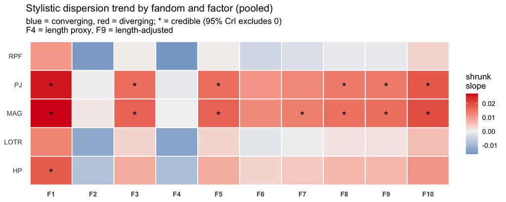

```r
plot_dispersion_heatmap(shrunk)
```

## 2. Raw vs pooled: how much did shrinkage change each estimate?

Open grey circle = raw stage-1 OLS slope; filled point + bar = pooled estimate with 95% CrI. Segment length shows how far partial pooling pulled each raw number — long segments are exactly the cells you should be most skeptical of if you only had the raw estimate.

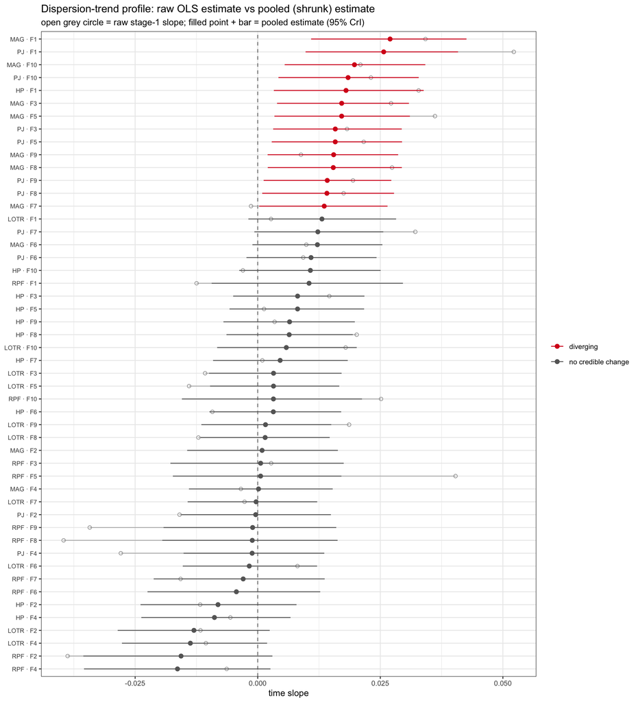

```r
plot_shrinkage_forest(shrunk)
```

## 3. Per-factor detail: binned dispersion over time

Binned mean |deviation from fandom median| against time, per fandom, with a loess smooth. Point size = bin n, so precision is visible directly. Useful for spotting non-linear patterns a linear `time` slope would average away (e.g. RPF’s F1 trend is U-shaped, not monotonic — worth remembering when reading its “no credible change” result in the main table).

```r
for (fk in FACTORS) {
  cat("### ", fk, "\n")
  print(plot_dispersion_trend(d, fk))
  cat("\n\n")
}
```

### F1

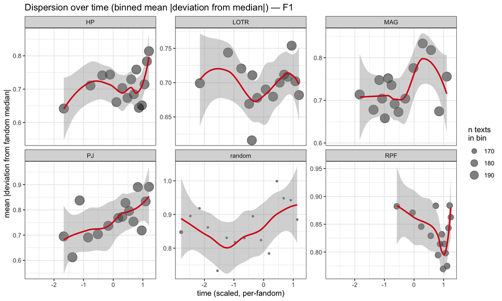

### F2

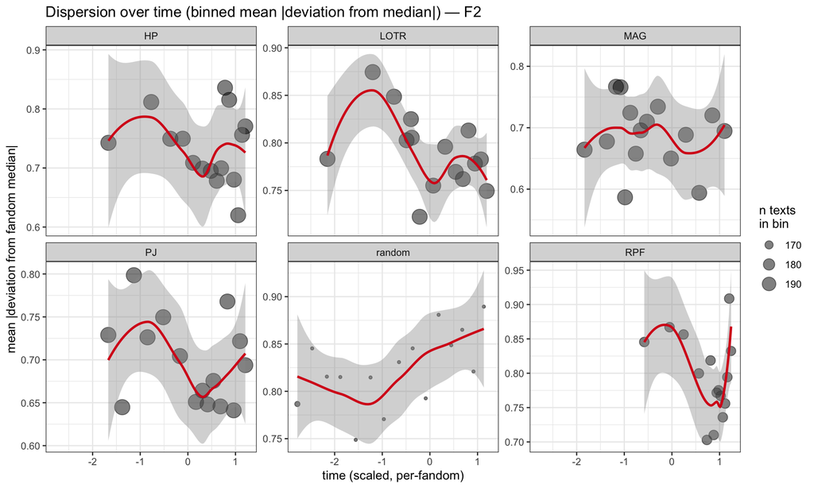

### F3

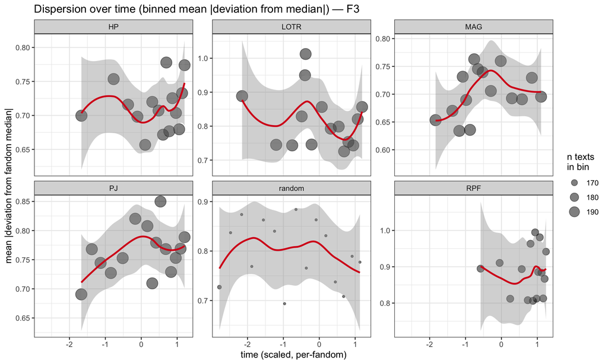

### F4

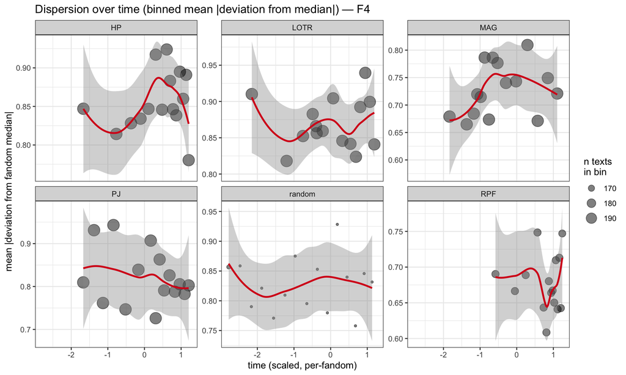

### F5

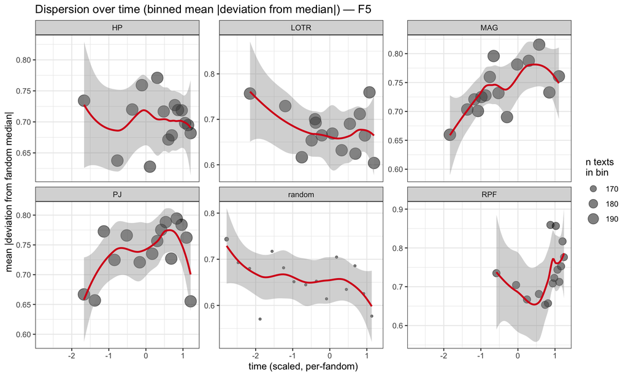

### F6

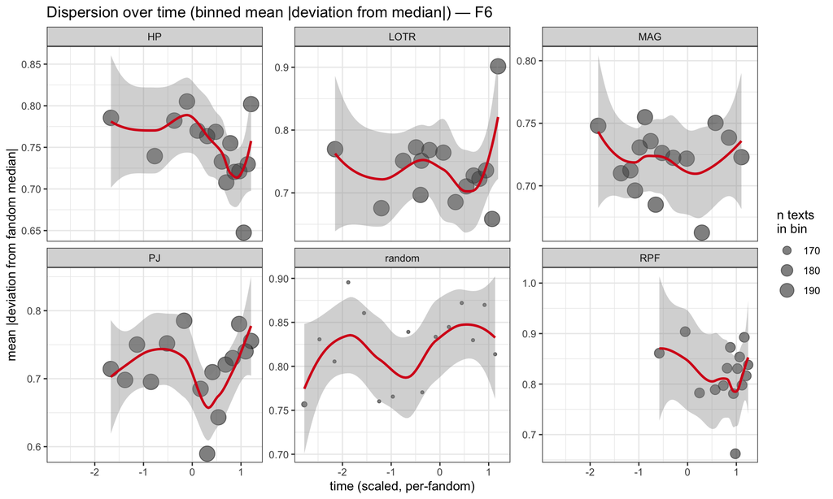

### F7

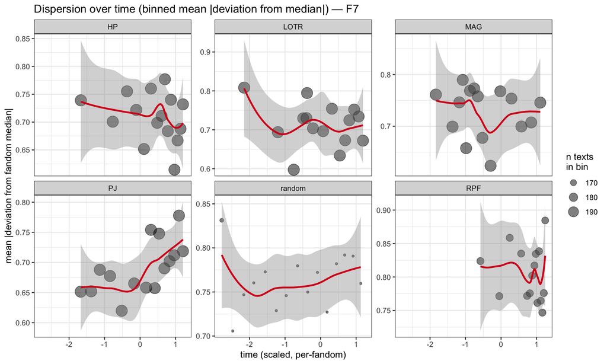

### F8

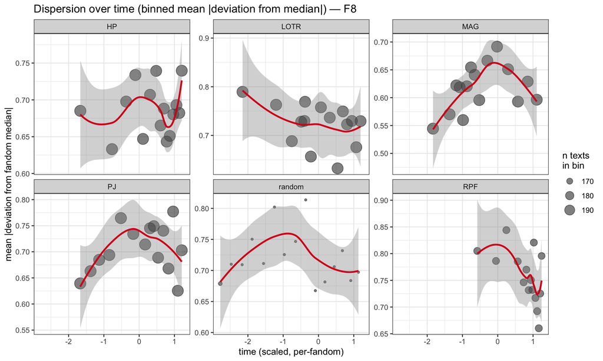

### F9

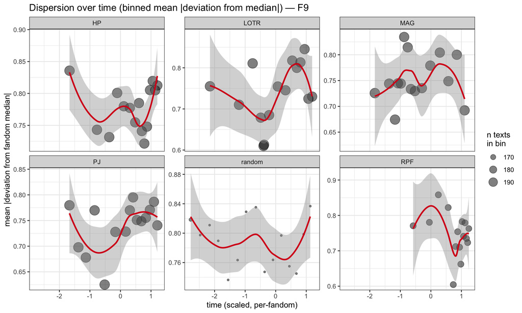

### F10

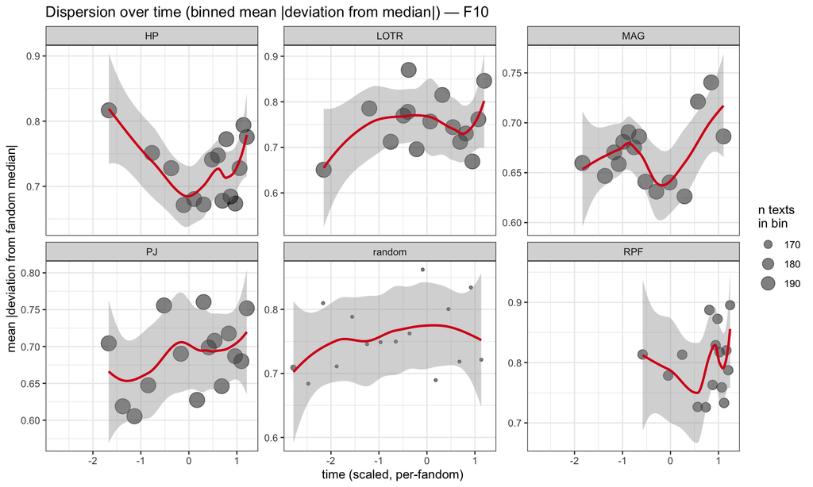

## 4. Rating x time interaction: does rating change the RATE of change?

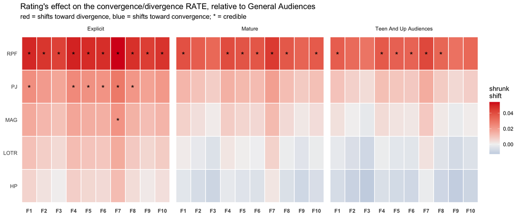

```r
plot_rating_time_heatmap(shrunk_rt)
```

### Per-factor detail, raw estimates by fandom

Unpooled `rating:time` estimates (95% CI), one panel per factor, color = fandom. Useful for seeing which specific fandom/rating pairs are driving the pooled result above.

```r
for (fk in FACTORS) {
  cat("#### ", fk, "\n")
  print(plot_rating_time_by_fandom(rating_time_effects, fk))
  cat("\n\n")
}
```

#### F1

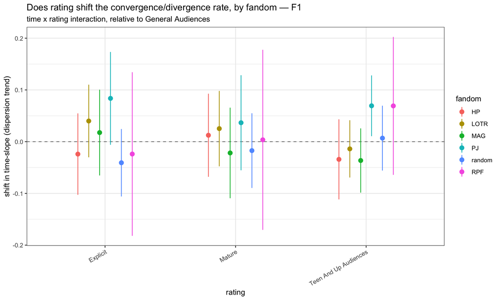

#### F2

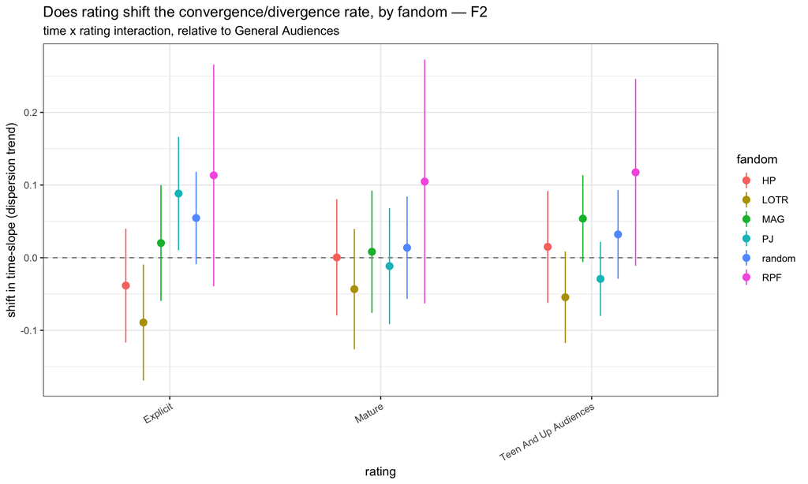

#### F3

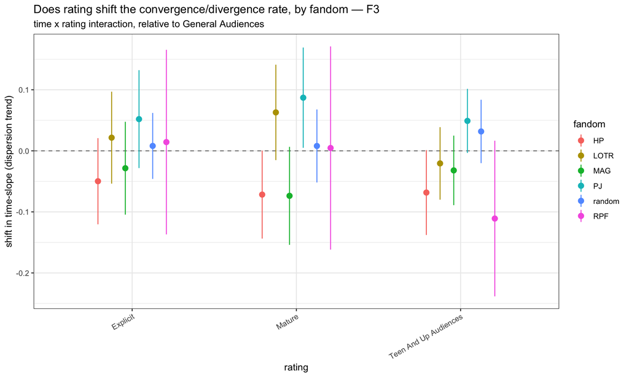

#### F4

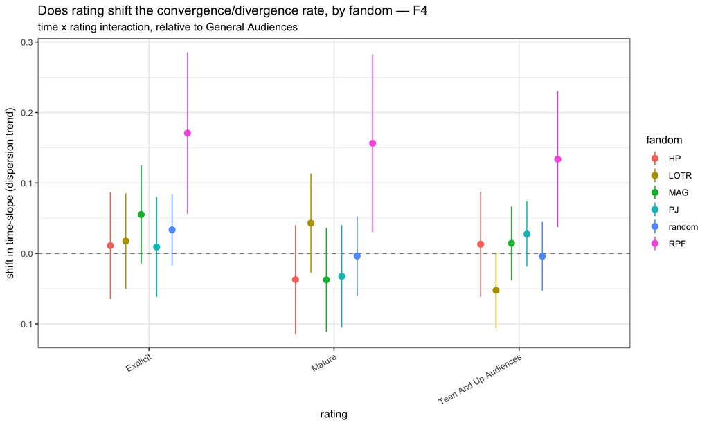

#### F5

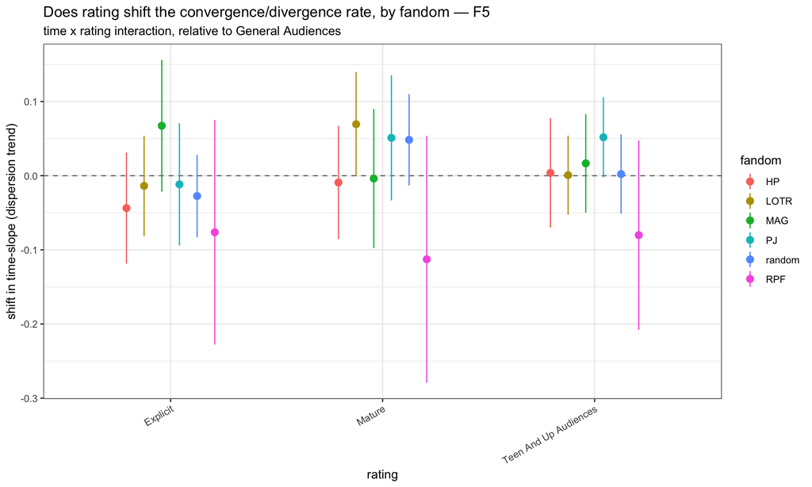

#### F6

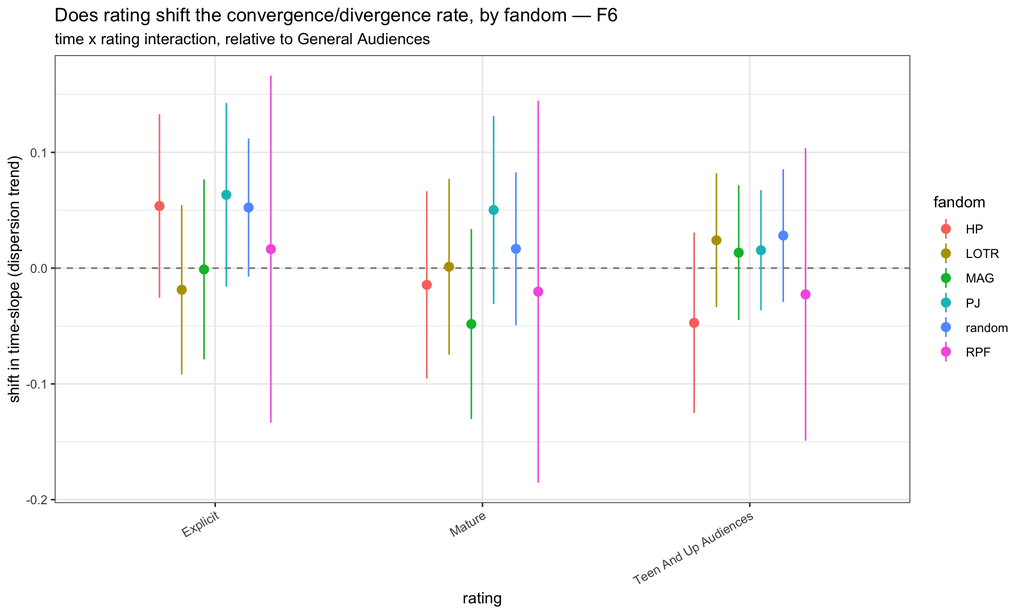

#### F7

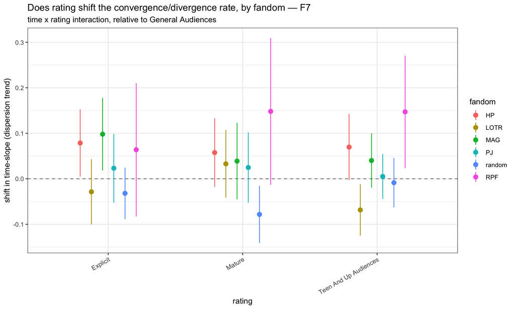

#### F8

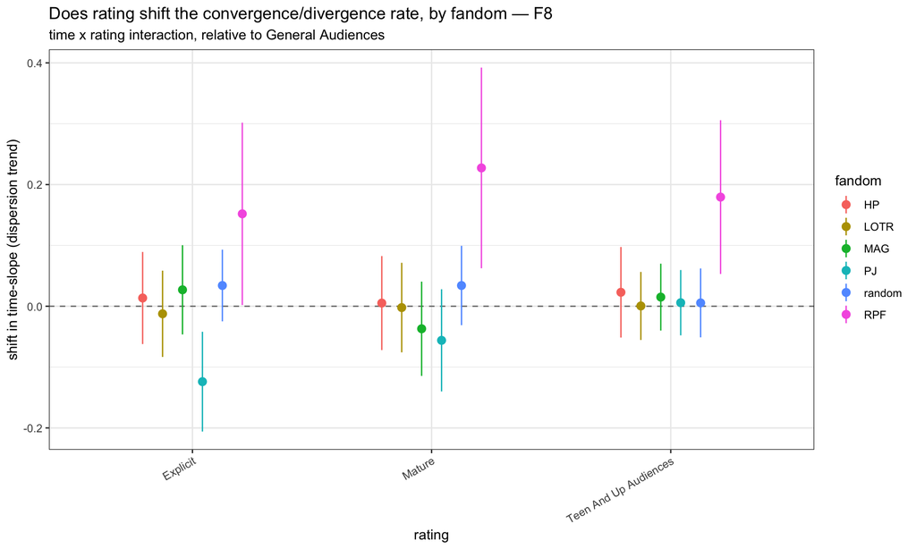

#### F9

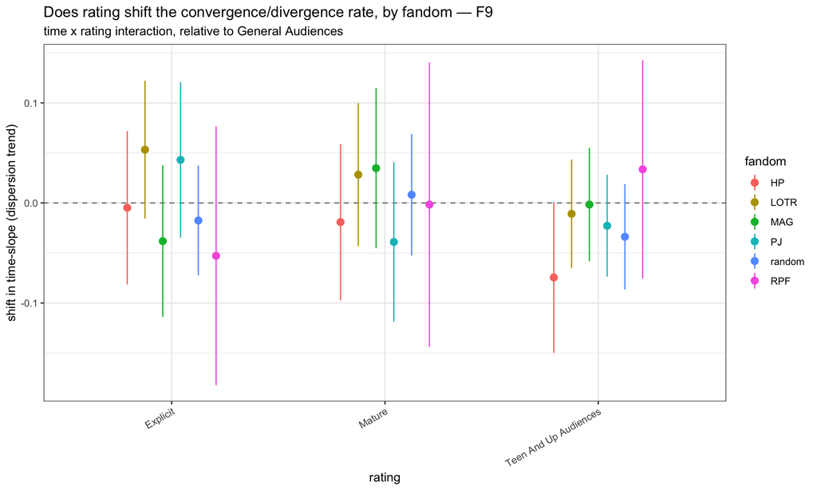

#### F10

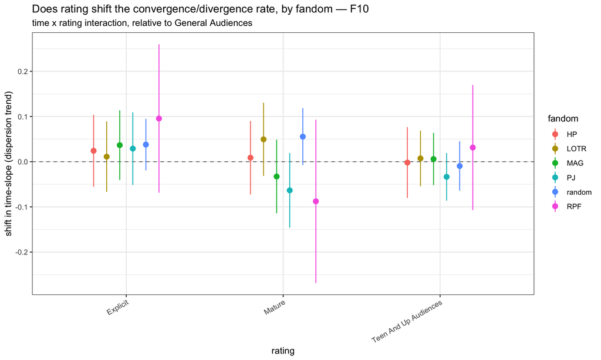

## 5. Rating x average dispersion level

This is new — the additive `rating` effect (does dispersion sit higher or lower overall for this rating, not its trend over time) was computed early in the pipeline but never visualized until now. It turned out to be far more pervasive than the interaction above (121 of 200 cells credible) and shows a clean split: F3/F4/F7/F8 (Negative Affect, length, Conversationality, Positive Affect) sit **lower** in rated content across nearly every fandom; F1/F9/F10 (Syntactic Complexity, Narrative Drift, Structural Variability) sit **higher**.

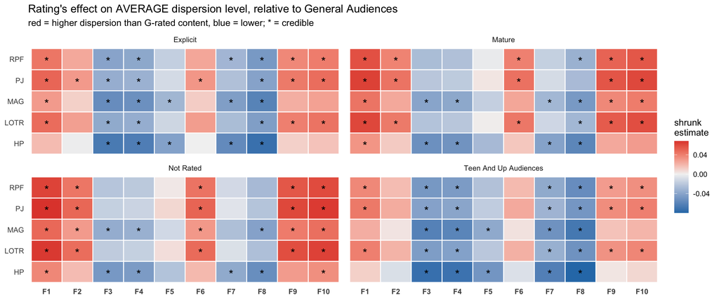

```r
plot_rating_level_heatmap(shrunk_rl)
```

## 6. Other metadata: logwords / growth_resid / is_new_author

Not pooled (nuisance covariates, not a primary question) — just a quick visibility pass so these aren’t left completely unexamined. `logwords` is a strong, expected control (longer texts deviate less from the median); `growth_resid` contributes little on its own; `is_new_author` shows a modest, plausible “newcomers are somewhat more idiosyncratic” pattern.

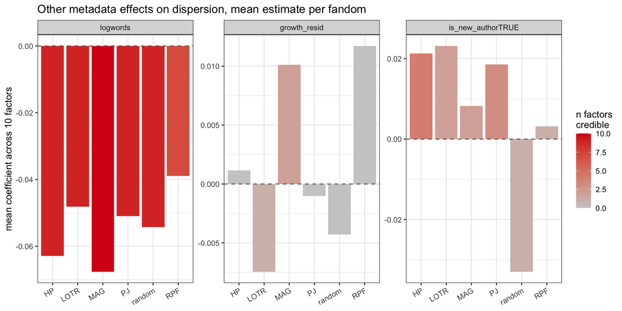

```r
other_metadata_summary %>%
  mutate(term = factor(term, levels = c("logwords", "growth_resid", "is_new_authorTRUE"))) %>%
  ggplot(aes(fandom, mean_estimate, fill = n_credible)) +
  geom_col() +
  geom_hline(yintercept = 0, linetype = 2, color = "grey40") +
  facet_wrap(~ term, scales = "free_y") +
  scale_fill_gradient(low = "grey80", high = "#d7191c", name = "n factors\ncredible") +
  labs(title = "Other metadata effects on dispersion, mean estimate per fandom",
       x = NULL, y = "mean coefficient across 10 factors") +
  theme_bw(base_size = 11) +
  theme(axis.text.x = element_text(angle = 30, hjust = 1))
```

## 7. Non-linearity robustness check

Motivated by looking at section 3’s trend plots — MAG and PJ’s F8 both show what looks like a rise-then-decline shape, not a straight line. For every credible cell in `shrunk`, refit with a flexible (natural spline) time term and check whether that curvature is statistically real, and whether the early-vs-late direction still agrees with the linear model’s label.

**Result: none of the 14 credible cells show significant non-linearity** (smallest p = .094, MAG-F8), and 13 of 14 keep the same direction under the flexible fit. The visual “hump” in MAG/PJ-F8 below is real in the point estimate, but the confidence ribbon is wide enough that a straight line stays plausible inside it — the linear results hold up.

```r
nonlinearity_check %>% arrange(nonlinear_p)
```

| fandom | factor | linear_direction | nonlinear_p | fitted_early | fitted_mid | fitted_late | net_change | shape_agrees_with_linear |
| --- | --- | --- | --- | --- | --- | --- | --- | --- |
| MAG | F8 | diverging | 0.09409457 | 0.6171427 | 0.7033206 | 0.6729068 | 0.05576412 | TRUE |
| PJ | F8 | diverging | 0.10804663 | 0.7001261 | 0.8028497 | 0.7505406 | 0.05041448 | TRUE |
| MAG | F1 | diverging | 0.11693560 | 0.5547710 | 0.7540327 | 0.6442713 | 0.08950030 | TRUE |
| HP | F1 | diverging | 0.14879734 | 0.6094104 | 0.6292239 | 0.7094887 | 0.10007830 | TRUE |
| PJ | F5 | diverging | 0.18864259 | 0.6792654 | 0.7626555 | 0.7154283 | 0.03616285 | TRUE |
| MAG | F10 | diverging | 0.31224582 | 0.6641198 | 0.5719441 | 0.7205119 | 0.05639215 | TRUE |
| MAG | F3 | diverging | 0.32200352 | 0.7317045 | 0.7155809 | 0.7828782 | 0.05117374 | TRUE |
| PJ | F10 | diverging | 0.36659218 | 0.6047705 | 0.6947517 | 0.6744483 | 0.06967786 | TRUE |
| PJ | F9 | diverging | 0.44230811 | 0.6879743 | 0.7127939 | 0.7112217 | 0.02324734 | TRUE |
| MAG | F7 | diverging | 0.54763013 | 0.7712434 | 0.6533271 | 0.7518746 | -0.01936882 | FALSE |

[output cut: 4 more lines]

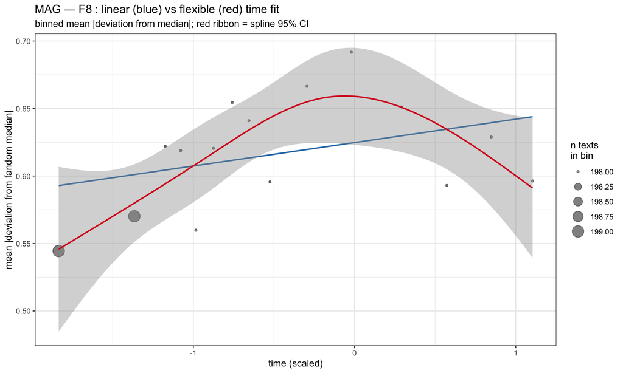

```r
print(plot_spline_comparison(d, "MAG", "F8"))
```

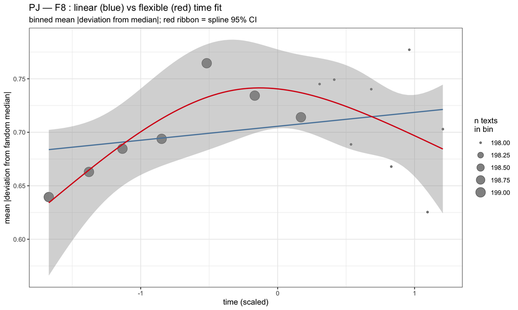

```r
print(plot_spline_comparison(d, "PJ", "F8"))
```

## 8. Collinearity checks (diagnostic, not a finding)

`growth_resid` is orthogonalized to `time` by construction — confirms it stayed that way for the OLS predictor set (section 6 of the script) and for the rating interaction’s predictor set (section 7’s `rating_time_collinearity`).

```r
vif_by_fandom
```

| fandom | term | vif |
| --- | --- | --- |
| HP | time | 1.008960 |
| HP | logwords | 1.019442 |
| HP | growth_resid | 1.001209 |
| HP | is_new_author | 1.011065 |
| LOTR | time | 1.003529 |
| LOTR | logwords | 1.010822 |
| LOTR | growth_resid | 1.002667 |
| LOTR | is_new_author | 1.007395 |
| MAG | time | 1.003467 |
| MAG | logwords | 1.007903 |

[output cut: 14 more lines]

```r
rating_time_collinearity %>% arrange(desc(incremental_r2_from_rating))
```

| fandom | incremental_r2_from_rating |
| --- | --- |
| RPF | 0.032586631 |
| LOTR | 0.012646283 |
| PJ | 0.006170604 |
| HP | 0.005248025 |
| MAG | 0.005187558 |
| random | 0.001964574 |